# **Exploratory Data Analysis (EDA):**

## **1. Introduction to Exploratory Data Analysis**

Exploratory Data Analysis (EDA) is a fundamental and indispensable step in the data science and machine learning pipeline. It refers to the process of **investigating, visualizing, summarizing, and understanding the key characteristics of a dataset before applying any modeling techniques**.

EDA helps uncover:

- The **underlying structure** of the data
- The presence of **missing values or outliers**
- The **distribution and variability** of features
- **Correlations and patterns** between variables
- **Initial assumptions** about the data that may affect model choice

In essence, EDA is like getting to know your data before trying to solve a problem with it—much like understanding a patient’s medical history before prescribing medication.

### **Key Objectives of EDA**

- Discover patterns and anomalies
- Test hypotheses
- Validate assumptions
- Prepare for feature engineering or model building
- Determine the **relevance and need** for applying machine learning

## **2. Why Do We Need EDA?**

### **A Real-Life Analogy: Planning a Family Vacation**

Imagine you're planning a family vacation. You wouldn't just book tickets and hotels without:

- Knowing the **budget**
- Understanding the **preferences** of family members (beach or mountains?)
- Considering **weather conditions**
- Looking at the **availability** of leave days

This investigation is much like EDA: you collect all relevant information before taking action.

### **Key Questions Answered During EDA**

| Question | Explanation |
| --- | --- |
| **Do I really need a model?** | Sometimes, simple aggregations (e.g., descriptive stats) are enough to solve the problem. |
| **What is the business problem?** | EDA helps quantify the problem. For instance, "10% of customers churn monthly" gives a clear size of the issue. |
| **Is there a clear signal in the data?** | Correlations, patterns, or trends between features and target can suggest learnable relationships. |
| **Is the data sufficient and balanced?** | EDA reveals if classes are imbalanced, if there’s sampling bias, or if critical fields are missing. |
| **What is the business value?** | Helps decide ROI: is it worth building a model to reduce churn by 5% if it costs $1M? |

#### **Example Scenario**

Suppose you're working with customer support data from a telecom company. You want to build a model to predict if a customer will leave.

**Questions to explore:**

- How many customers have left in the last 12 months? (**Size of problem**)
- Are churned customers mostly from a particular region or age group? (**Root cause analysis**)
- Can this be solved with basic filtering and KPIs? (**Do we even need ML?**)
- Does churn correlate with call drop rate or service usage? (**Signal discovery**)

These insights **guide whether to proceed with modeling, how complex the model should be**, and what kind of data preprocessing is needed.

## **3. How to Approach EDA**

EDA is **not a one-size-fits-all** process, but a structured workflow makes it efficient and insightful. Here's a step-by-step breakdown:

### **3.1 Check for Missing (Null) Values**

#### **Purpose**

The first question every data scientist must ask is: where is the data missing? Null or missing values are not just gaps—they are signals. Their presence can indicate measurement failure, system error, or even patterns in human behavior. For instance, if income data is missing mostly for a specific age group, that might carry socioeconomic implications.

We analyze missing values column-wise and row-wise, using tools like heatmaps or missingness matrices. If missingness is random (MCAR), imputations like mean or median work well. If it's conditionally dependent on observed data (MAR), techniques like MICE (Multiple Imputation by Chained Equations) or KNN imputation are preferred. However, if data is not missing at random (NMAR), we may need to model the missingness itself or flag it as an informative variable.

#### **Techniques**

- **Count nulls per column:** `df.isnull().sum()`
- **Visualize missing data:** Using libraries like `missingno` or `seaborn.heatmap()`
- **Decide imputation or deletion**:
  - **Delete** if too many nulls or if the feature isn't useful
  - **Impute** with:
    - Mean/Median/Mode (univariate)
    - KNN Imputer (multivariate)
    - Iterative Imputer (based on regression)

#### **Mathematical Formulas**

- **Mean imputation:** $x_i = \frac{\sum_{j=1}^{n} x_j}{n} \quad \text{where } x_j \text{ is not null}$
- **Z-score method (for detecting null effects on distribution):** $z = \frac{x - \mu}{\sigma}$

### **3.2 Check for Outliers**

Outliers are data points that significantly differ from the rest. While they may indicate data entry errors, they can also reveal rare but meaningful occurrences—like a customer who spends 10x the average. Understanding outliers is vital because they can skew mean-based statistics, distort scaling, and mislead algorithms that are sensitive to data magnitude.

#### **Purpose**

Outliers can:

- Skew distributions
- Impact model performance (especially linear models)
- Indicate data entry errors or extreme variability

#### **Detection Methods**

- **Boxplots** (IQR method): Outlier if: $x < Q1 - 1.5 \times IQR \quad \text{or} \quad x > Q3 + 1.5 \times IQR$
- **Z-score method**: Outlier if $|z| > 3$
- **Isolation Forest / LOF (for multivariate outliers)**

#### **Treatment Techniques**

- Remove or replace
- Log transformation
- Capping (winsorization)
- Clustering-based grouping

### **3.3 Analyze Target Variable Distribution**

The target variable—the outcome we want to predict—must be carefully studied. If it's categorical, we analyze class distribution, detect imbalance, and calculate entropy or Gini impurity. If it’s numerical, we inspect its shape using histograms, density plots, and statistical moments (mean, variance, skewness, kurtosis).

For instance, if the target variable (like house price) is heavily right-skewed, applying models that assume normality (like linear regression) will underperform. In such cases, transformation techniques such as logarithmic scaling or Box-Cox transformation are employed.

#### **Why Important**

Understanding the **distribution of the target** helps:

- Determine if data is **imbalanced** (e.g., in classification tasks)
- Choose appropriate evaluation metrics (e.g., Accuracy vs F1)
- Identify **bias** or **skewness**

#### **Tools**

- Histograms
- Bar plots
- `value_counts(normalize=True)`
- Skewness metric: $\text{Skewness} = \frac{E[(X - \mu)^3]}{\sigma^3}$

### **3.4 Analyze Individual Feature Distributions**

Each individual feature is then examined to understand its univariate distribution. For numerical features, histograms and KDE plots are used. For categorical features, bar plots and frequency tables provide insights.

#### **Objective**

To understand:

- Whether features are continuous or categorical
- Their spread, central tendency, skewness, and modality

#### **Steps**

- Use `df.describe()` for numeric features
- Plot:
  - Histograms (for numeric)
  - Bar charts (for categorical)
  - KDE plots (to examine density)
- Apply log transformation or normalization if needed

#### **Mathematical Descriptors**

- **Mean:** $\mu = \frac{1}{n} \sum x_i$
- **Variance:** $\sigma^2 = \frac{1}{n} \sum (x_i - \mu)^2$
- **Skewness and Kurtosis**

Beyond univariate analysis, we study **bivariate relationships**:

- Correlation matrices for numeric variables
- Chi-square tests for categorical relationships
- Boxplots to visualize numeric-categorical interactions

This step highlights multicollinearity, helps select the most informative variables, and sets the stage for modeling.

### **3.5 Understand Feature-Target Relationships**

This step is crucial for discovering which features may influence the target variable.

#### **Techniques Based on Feature Types**

| Feature Type | Target Type | Suggested Analysis |
| --- | --- | --- |
| Continuous | Continuous | Correlation (Pearson, Spearman), scatter plots |
| Categorical | Categorical | Crosstab, Chi-Square Test |
| Continuous | Categorical | Boxplots, ANOVA |
| Categorical | Continuous | Grouped bar charts, Aggregation |

#### **Example Tools and Visuals**

- Correlation matrix (`df.corr()`)
- Heatmaps
- Pairplots (Seaborn)
- Feature importance (RandomForest or SHAP)

#### **Example Analysis**

If higher monthly charges correlate with customer churn, we could model that as a predictive signal.

## **Distribution and Single Variable Analysis in EDA**

### **Importance of Single Variable (Univariate) Analysis in EDA**

Univariate analysis involves examining each variable individually. This helps in:

- Understanding the **central tendency** (mean, median, mode)
- Analyzing **dispersion** (variance, standard deviation, range)
- Detecting **outliers**
- Examining **distribution shape** (e.g., normal, skewed, uniform)

Especially for **numerical variables**, understanding the **distribution** is critical. Some statistical and machine learning models (like Linear Regression, Logistic Regression, LDA, Naive Bayes, etc.) assume that variables are **normally distributed**. If this assumption is violated, it can degrade model performance, increase errors, or bias the results.

### **Key Tools for Single Variable Analysis**

- **Histograms** – show frequency distribution
- **Kernel Density Estimation (KDE)** – smoothed version of histogram
- **Boxplots** – reveal spread, central values, and outliers
- **QQ-Plots** – compare data distribution to theoretical normal distribution

### **Understanding Types of Distributions**

Let's look at the most commonly used probability distributions. We will also see the **mathematical or structural relationships**, showing how one distribution can **approximate, derive from, or converge to** another.

At the top, we have the **Uniform distribution**, which assumes all outcomes are equally likely. This forms the basis for random simulations. The **Bernoulli distribution** stems from this concept when we restrict the outcome to two values: 0 and 1 (e.g., coin toss). When Bernoulli trials are repeated $n$ times, we get the **Binomial distribution**, which models the probability of $k$ successes in $n$ trials. If trials are done without replacement, we land on the **Hypergeometric distribution**.

Now, when the number of trials $n$ becomes very large and probability $p$ very small, the Binomial distribution approximates the **Poisson distribution**, which is used for modeling count data. The **Exponential distribution** complements Poisson by modeling the time between such events. It is memoryless, making it ideal for queuing systems.

The **Weibull distribution** generalizes the Exponential by adjusting the hazard rate, making it useful in survival analysis. Extending Weibull leads us to the **Gamma distribution**, and further into **Beta distribution**, which is perfect for modeling variables that lie between 0 and 1, such as probabilities.

The **Normal (Gaussian) distribution**, central to classical statistics, is derived from the Central Limit Theorem, which states that the mean of a large number of independent variables tends toward normality. The **Chi-Squared distribution** arises when we square and sum standard normal variables. The **Student’s t-distribution** generalizes this by adjusting for smaller sample sizes.

These distributions form the mathematical foundation for modeling assumptions, statistical tests, and feature engineering transformations.

Let’s explore each distribution:

#### 1.**Uniform Distribution**

- **Shape:** Flat – all values are equally likely.
- **Use case:** Random number generation, simulation.
- **Example:** Rolling a fair die (Discrete), generating a random float between 0 and 1 (Continuous).

#### 2. **Bernoulli Distribution**

- **Binary outcome:** 1 (success), 0 (failure).
- **Parameter:** Probability of success $p$
- **Example:** Tossing a coin once.

#### 3. **Binomial Distribution**

- **Discreet distribution of successes in $n$ Bernoulli trials**.
- $P(X = k) = \binom{n}{k} p^k (1-p)^{n-k}$
- **Example:** Number of heads in 10 coin tosses.

#### 4.**Hypergeometric Distribution**

- Like Binomial but **without replacement**.
- Used in quality control, lotteries.

#### 5. **Geometric Distribution**

- Models the number of **trials until the first success**.
- Right-skewed.

#### 6. **Negative Binomial Distribution**

- Generalization of Geometric for **k successes**.
- Models **overdispersed count data** (variance > mean).

#### 7. **Poisson Distribution**

- Models **number of occurrences** of an event in a fixed interval.
- $P(X = k) = \frac{\lambda^k e^{-\lambda}}{k!}$
- Used in queue theory, call center, web hits.
- Derived from Binomial under low probability, large $n$.
- Approximate **Normal** when $\lambda$ is large.

#### 8. **Exponential Distribution**

- Models **time between events** in a Poisson process.
- Memoryless.
- $f(x; \lambda) = \lambda e^{-\lambda x}$

#### 9. **Weibull Distribution**

- Generalization of exponential.
- Used in reliability engineering, survival analysis.
- Flexible shape controlled by **shape and scale parameters**.

#### 10. **Chi-Squared Distribution**

- Special case of Gamma.
- $\chi^2_k \sim \sum_{i=1}^{k} Z_i^2$, where $Z_i \sim N(0,1)$
- Common in hypothesis testing (goodness of fit, independence).
- Derived from **Normal** squared values.

#### 11. **Gamma Distribution**

- General distribution for **waiting times**.
- Two parameters: shape (k), scale (θ)
- Special case of **Exponential** (when shape=1).

#### 12. **Beta Distribution**

- For modeling **probabilities**, bounded between 0 and 1.
- Flexible shape.
- Great for **Bayesian** analysis (prior distributions).

#### 13. **Log-Normal Distribution**

- If a variable is log-transformed and normally distributed, the original variable is log-normal.
- **Example:** Stock prices, income data.

#### 14. **Student’s t-Distribution**

- Similar to normal but with heavier tails.
- Used when **sample size is small**, or **population variance is unknown**.
- Converges to normal with larger samples.

#### 15. **Normal Distribution (Gaussian)**

- Bell-shaped curve.
- Defined by mean $\mu$ and standard deviation $\sigma$.
- $f(x) = \frac{1}{\sqrt{2\pi\sigma^2}} e^{-(x-\mu)^2/2\sigma^2}$
- Central to many ML models and the Central Limit Theorem (CLT).

## **How to Theoretically Calculate Distribution**

### **For Numerical Targets:**

- Use **frequency histograms**, **density plots**, **summary statistics**:
  - Mean: $\mu = \frac{1}{n} \sum x_i$
  - Variance: $\sigma^2 = \frac{1}{n} \sum (x_i - \mu)^2$
  - Skewness, Kurtosis for shape analysis
- Use `scipy.stats` or `statsmodels` for testing normality:
  - Shapiro-Wilk test
  - Anderson-Darling test
  - D’Agostino’s K-squared test

### **For Categorical Targets:**

- Use **frequency counts** and **bar plots**
- Calculate **class proportions**
  - $p_i = \frac{\text{count of class } i}{\text{total observations}}$

### **Imbalanced Dataset: What, Why, and How to Fix**

#### **Definition:**

An imbalanced dataset occurs when the classes in a classification problem are not represented equally. This is a common challenge in fraud detection, medical diagnosis, or rare event prediction. For example, if 98% of emails are non-spam and only 2% are spam, a model can achieve 98% accuracy by always predicting “non-spam”—but it completely fails in detecting the rare, crucial spam emails.

The severity of imbalance is quantified using ratios and metrics such as Precision, Recall, and F1-Score, which penalize false negatives or positives more than overall accuracy. We can also plot ROC curves to examine the trade-off between sensitivity and specificity.

To address imbalance, several techniques are used:

- **Oversampling the minority class**, either through replication or synthetic methods like SMOTE, which generates new instances along the lines connecting minority samples.
- **Undersampling the majority class**, where random observations from the dominant class are removed.
- **Cost-sensitive learning**, where the model penalizes errors on the minority class more heavily.
- **Using ensemble algorithms** like Random Forest or XGBoost that can internally handle class weights or sampling imbalance.

These operations are not optional; if class imbalance is not addressed, the model may appear accurate but fail in real-world deployment, particularly in high-stakes domains like healthcare or finance.

#### **Metrics to Use Instead of Accuracy:**

- Precision
- Recall
- F1-Score
- ROC-AUC
- Confusion Matrix

### **Few other Techniques to Handle Imbalanced Datasets**

#### **1. Algorithmic Techniques**

- Use models that handle imbalance (e.g., XGBoost, CatBoost)
- Penalize misclassification of minority class via class weights:
  - `class_weight='balanced'` in `sklearn`

#### **2. Ensemble Techniques**

- **Bagging with stratified sampling**
- **Boosting with sample weighting**

#### **3. Threshold Moving**

- Adjust the classification threshold to favor minority prediction.

## Relationships and Multivariable Plots in Exploratory Data Analysis (EDA)

### **Understanding Relationships in Data: The Soul of Pattern Discovery**

While understanding individual variables is essential to grasp the distribution, central tendency, and presence of outliers, the true power of data science is revealed when we begin to investigate **how variables relate to each other**. This is the essence of predictive modeling—not merely describing variables in isolation, but **studying their interactions and dependencies**.

Just as human behavior cannot be explained by a single trait like age or income alone, most phenomena in data cannot be fully understood through univariate analysis. A single variable might reveal little by itself but may tell a powerful story when **combined with others**. This is why relationship analysis and **multivariable exploration** are critical.

## **Why Studying Relationships Matters in EDA**

Exploring relationships between variables serves several interrelated purposes:

### 1. **Predictive Feature Insight**

The ultimate goal of modeling is to **predict** a target variable. Studying bivariate and multivariate relationships helps identify which features have **predictive power** and which do not. For example, a feature that varies significantly across different values of the target variable is more likely to be a strong predictor.

### 2. **Detection of Multicollinearity**

Multicollinearity refers to the presence of high correlation between two or more independent variables. In linear models like **Linear Regression**, this is particularly problematic, as it can:

- Inflate variance of coefficient estimates
- Make model coefficients unstable and sensitive to minor changes
- Mislead the interpretability of variable importance

Therefore, identifying and quantifying relationships between features allows you to make decisions such as:

- Removing highly correlated features
- Combining them through techniques like PCA
- Using models that are robust to multicollinearity (like tree-based models)

### 3. **Interaction Effects**

Some variables may **not** show strong correlation with the target in isolation but may reveal predictive power when interacting with other variables. This is especially useful in nonlinear models. For instance, a customer’s satisfaction level may depend on both product quality and customer service—not each independently, but in **combination**.

### 4. **Discovery of Direct Insights**

Sometimes, relationships between features yield **immediate, actionable business insights** even before modeling begins. For example:

- In fraud detection, a strong relationship between transaction amount and transaction time may directly indicate fraudulent behavior.
- In churn prediction, a strong inverse relationship between usage frequency and churn status may suggest that increasing engagement is key to customer retention.

Such insights can directly inform **business decisions**, **policy changes**, and **product improvements**, making EDA not just a technical step but also a strategic one.

## **Visualizing Relationships: Multivariable Plot Techniques**

Relationships are best visualized using **multivariate plotting techniques**. These plots not only show interactions between two or more variables but also expose **hidden trends, nonlinear patterns, segmentation**, and **outliers** that go unnoticed in tabular views or simple univariate plots.

Let’s break down the major tools used in relationship analysis:

### **1. Scatter Plot**

A scatter plot is the most basic tool for visualizing the relationship between two **numerical variables**. Each point represents an observation, plotted by its values on the x- and y-axes.

- A **positive slope** indicates a direct relationship (as one increases, so does the other).
- A **negative slope** indicates an inverse relationship.
- A **clustered** pattern might indicate a subgroup or segmentation.
- A **curved pattern** suggests a nonlinear relationship.

When the target variable is categorical, color-coding the points by class allows us to detect **class separation** or **overlap**, which helps assess the feasibility of classification models.

### **2. Correlation Matrix and Heatmap**

The correlation coefficient quantifies the **linear relationship** between two variables. The most commonly used metric is **Pearson’s correlation coefficient**, which ranges from -1 to +1.

- $r = +1$ implies a perfect positive linear relationship.
- $r = -1$ implies a perfect negative linear relationship.
- $r = 0$ implies no linear relationship.

The **correlation matrix** presents pairwise correlations between all numeric features, while a **heatmap** visualizes this in a color-coded grid. This is an essential step in detecting multicollinearity and guiding feature selection or dimensionality reduction.

### **3. Pair Plot (also called Scatterplot Matrix)**

A pair plot creates scatter plots for every pair of numerical features in a dataset, along with histograms on the diagonal. This allows you to examine relationships and distributions simultaneously.

It also includes **color-coding by a target variable**, helping visualize how different features jointly behave across different classes.

### **4. Box Plot / Violin Plot**

When examining the relationship between a **categorical variable** (e.g., customer segment) and a **numerical variable** (e.g., income), box plots provide a visual representation of:

- Median
- Quartiles
- Range
- Outliers

Violin plots go a step further by overlaying a **KDE (Kernel Density Estimate)** curve, showing the shape of the distribution in each category.

This is crucial when evaluating whether the distribution of a feature differs meaningfully across different target classes or groups.

### **5. Facet Grids and Subplots**

Sometimes, relationships can only be interpreted in the **context of another categorical variable**. Facet grids (such as Seaborn’s `FacetGrid`) allow for creating **small multiples**—subplots of the same chart split by different values of a third variable (e.g., gender, location, or region).

This is extremely helpful for:

- Segment analysis
- Time-based pattern evaluation
- Conditioned relationships

### **6. 3D Plots and Parallel Coordinates**

When studying relationships across **three or more variables**, 3D plots (like matplotlib’s `Axes3D`) or **parallel coordinates plots** can be used to visualize high-dimensional interactions.

Though more complex, they help in detecting:

- Interactions
- Redundancies
- Segmentation in feature space

These are often used for feature importance discovery and dimensionality reduction strategies.

## **Mathematical Relationships Behind the Visuals**

Beyond the visual, it’s important to recognize that relationships are quantified using metrics such as:

- **Pearson correlation**: $r = \frac{\sum (x_i - \bar{x})(y_i - \bar{y})}{\sqrt{\sum (x_i - \bar{x})^2 \sum (y_i - \bar{y})^2}}$
- **Spearman rank correlation**: Measures monotonic relationships (not just linear).
- **Mutual Information**: Measures the amount of information one variable contains about another; useful for nonlinear and categorical interactions.
- **Chi-square test**: Tests the independence of two categorical variables.
- **ANOVA (Analysis of Variance)**: Tests if the mean of a numeric variable differs across groups defined by a categorical variable.

Each of these tools helps confirm or disprove relationships observed in the visualizations.

## **Insights from Relationship Analysis: The Gold of EDA**

This step of EDA often leads to what is called **direct insights**—discoveries that do not require a model to validate. For instance:

- Discovering that customers with high complaint frequency and low product satisfaction are 4x more likely to churn.
- Observing that loan default is strongly correlated with low income and a high debt-to-income ratio.
- Realizing that high product returns are concentrated in one specific region or seller category.

Such insights can be acted upon **immediately**: modifying business policies, prioritizing risk cases, or redesigning product features—even before deploying any machine learning system.

## **Final Words: Relationship Analysis Is Where Modeling Begins**

Understanding relationships is not just a data science best practice—it’s the **foundation of intelligence** within the data. The way variables interact shapes the choice of algorithms, the formulation of hypotheses, and the design of features. It reveals the **true complexity** of the problem, uncovers latent factors, and equips you with the knowledge to not just predict—but explain and influence outcomes.

## Understanding Relationships in EDA: Visualizing, Correlating, and Distinguishing Causality

### **Scatterplots: An Essential Tool to Visualize Numerical Relationships**

A **scatterplot** is one of the most fundamental visualizations in EDA used to study the relationship between two **numerical variables**. It helps us detect linear and nonlinear trends, clusters, outliers, and most importantly, whether two variables **move together**.

Each point in a scatterplot represents an observation, with its horizontal position determined by the value of one variable (`X`) and its vertical position by the value of another variable (`Y`).

#### When to Use Scatterplots

- Both variables must be **continuous (numerical)**.
- You are trying to detect **trends, relationships, or associations**.
- You want to compute or visualize **correlation coefficients**.

Let’s visualize this through **dummy data** that demonstrates different levels and directions of correlation.

#### Python Code: Demonstrating Positive, Negative, and No Correlation

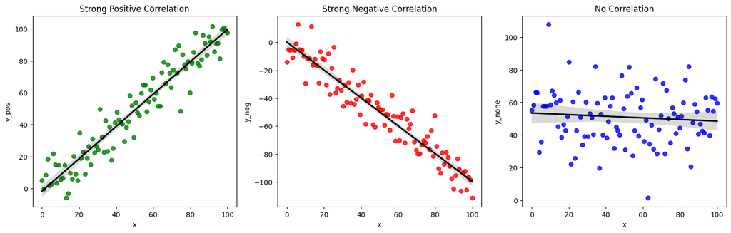

```
Positive Correlation Coefficient: 0.9563964230419771
Negative Correlation Coefficient: -0.9507302852681064
No Correlation Coefficient: -0.089519560313744
```

```python
import numpy as np
import pandas as pd
import seaborn as sns
import matplotlib.pyplot as plt

# Creating dummy data
np.random.seed(42)
x = np.linspace(0, 100, 100)
y_pos_corr = x + np.random.normal(0, 10, 100)            # Strong Positive
y_neg_corr = -x + np.random.normal(0, 10, 100)           # Strong Negative
y_no_corr = np.random.normal(50, 15, 100)                # No Correlation

# Building dataframe
df = pd.DataFrame({'x': x, 'y_pos': y_pos_corr, 'y_neg': y_neg_corr, 'y_none': y_no_corr})

# Plotting scatterplots
fig, axs = plt.subplots(1, 3, figsize=(18, 5))

sns.regplot(x='x', y='y_pos', data=df, ax=axs[0], color='green', line_kws={"color":"black"})
axs[0].set_title("Strong Positive Correlation")

sns.regplot(x='x', y='y_neg', data=df, ax=axs[1], color='red', line_kws={"color":"black"})
axs[1].set_title("Strong Negative Correlation")

sns.regplot(x='x', y='y_none', data=df, ax=axs[2], color='blue', line_kws={"color":"black"})
axs[2].set_title("No Correlation")

plt.show()

# Correlation coefficients
print("Positive Correlation Coefficient:", df['x'].corr(df['y_pos']))
print("Negative Correlation Coefficient:", df['x'].corr(df['y_neg']))
print("No Correlation Coefficient:", df['x'].corr(df['y_none']))
```

> The **correlation coefficient** (`Pearson’s r`) here quantifies the **strength** and **direction** of the relationship:
- $r = +1$: perfect positive
- $r = -1$: perfect negative
- $r = 0$: no linear relationship

## Correlation vs Causation: A Critical Distinction

One of the biggest misconceptions in data science is **mistaking correlation for causation**.

### What is Correlation?

Correlation refers to a **statistical association** between two variables. If two variables are correlated, it means that when one changes, the other tends to change as well—either in the same direction (positive) or in opposite directions (negative).

- **Example**: Ice cream sales and drowning incidents are positively correlated—but **eating ice cream doesn’t cause drowning**. The confounding factor here is temperature: in summer, both increase.

### What is Causation?

Causation implies a **direct effect**. That is, **changes in one variable cause changes in another**. Causation must satisfy these conditions:

1. The cause precedes the effect.
2. There is a relationship between cause and effect.
3. Other variables are ruled out.
- **Example**: Smoking causes lung cancer. It’s not just correlation; there is a biological mechanism behind it.

### Why the Difference Matters in EDA?

Detecting correlation is important for feature selection and modeling. But making **business decisions** or drawing **scientific conclusions** based on correlation alone is **dangerous** unless causality is verified—usually through controlled experiments, A/B testing, or advanced statistical modeling (e.g., Granger causality, instrumental variables).

## Correlation Matrix: A Tool to Summarize Relationships

A **correlation matrix** is a symmetric table that displays pairwise correlations between numerical features. It is particularly useful when you have **multiple variables**, and want to understand interrelationships at a glance.

### Python Code: Creating and Visualizing a Correlation Matrix

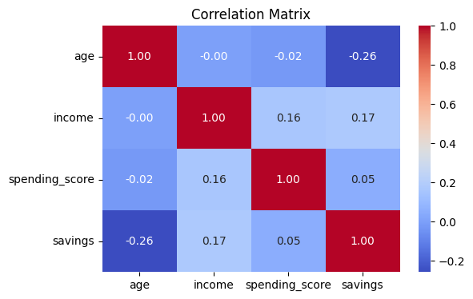

```python
# Create a dummy dataset
np.random.seed(0)
data = pd.DataFrame({
    'age': np.random.randint(18, 70, 100),
    'income': np.random.normal(50000, 12000, 100),
    'spending_score': np.random.uniform(0, 100, 100),
    'savings': np.random.normal(15000, 5000, 100)
})

# Compute correlation matrix
corr_matrix = data.corr()

# Visualize with seaborn heatmap
plt.figure(figsize=(6, 4))
sns.heatmap(corr_matrix, annot=True, cmap='coolwarm', fmt=".2f")
plt.title("Correlation Matrix")
plt.show()
```

## Visualizing Categorical and Numerical Data: Bar Charts, Line Charts, and Pivot Tables

In EDA, when analyzing **categorical data**, the goal is often to:

- Understand **frequency distributions**
- Compare numerical statistics **across groups**
- Identify dominant or under-represented classes

### Bar Charts (Categorical vs Count or Mean of Numerical)

- Ideal when plotting categorical variables.
- Helps visualize the frequency of categories or numerical summaries (mean/median) across categories.

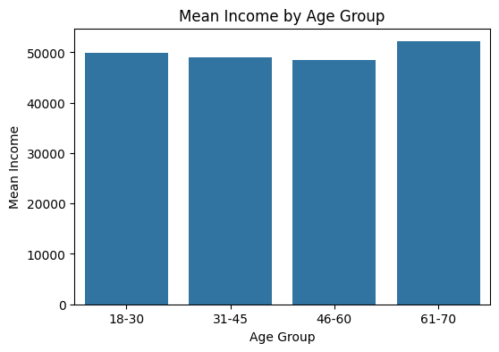

```python
# Bar chart showing mean income by age group
data['age_group'] = pd.cut(data['age'], bins=[18, 30, 45, 60, 70], labels=['18-30', '31-45', '46-60', '61-70'])
grouped = data.groupby('age_group', observed=True)['income'].mean().reset_index()

plt.figure(figsize=(6, 4))
sns.barplot(x='age_group', y='income', data=grouped)
plt.title("Mean Income by Age Group")
plt.ylabel("Mean Income")
plt.xlabel("Age Group")
plt.show()
```

### Line Charts (Temporal or Ordered Categorical Data)

- Ideal for trend analysis across **ordered categories** or **time**.
- Suitable for continuous variables over a fixed interval.

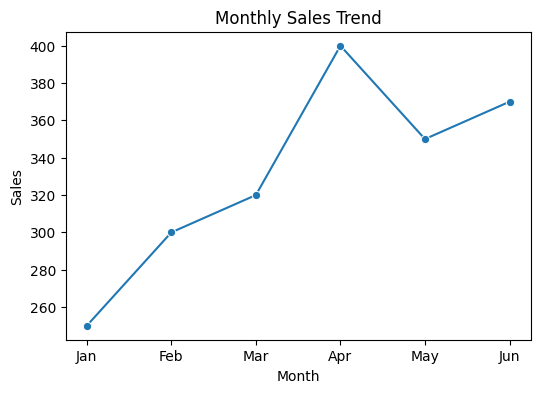

```python
# Dummy monthly data
months = ['Jan', 'Feb', 'Mar', 'Apr', 'May', 'Jun']
sales = [250, 300, 320, 400, 350, 370]
df_line = pd.DataFrame({'Month': months, 'Sales': sales})

plt.figure(figsize=(6, 4))
sns.lineplot(data=df_line, x='Month', y='Sales', marker='o')
plt.title("Monthly Sales Trend")
plt.show()
```

### Pivot Tables in EDA

A **pivot table** provides a **tabular summary** of a variable or statistic split across one or more dimensions. It’s invaluable for EDA involving:

- Grouped summaries
- Aggregated metrics
- Category-wise comparison

```python
# Pivot table of average spending score by age group and savings category
data['savings_category'] = pd.cut(data['savings'], bins=[0, 10000, 20000, 50000], labels=['Low', 'Medium', 'High'])
pivot = pd.pivot_table(data, values='spending_score', index='age_group', columns='savings_category', aggfunc='mean', observed=True)
pivot
```

| savings_category age_group | Low | Medium | High |
| --- | --- | --- | --- |
| 18-30 | 46.030746 | 56.707249 | 41.379919 |
| 31-45 | 54.887081 | 61.369281 | 72.460556 |
| 46-60 | 29.883328 | 53.791765 | 21.488074 |
| 61-70 | 53.093474 | 58.216880 | 42.545154 |

## Other EDA Methods: Beyond Visualization

While visual plots are the heart of EDA, they are complemented by statistical and even preliminary modeling approaches.

### Statistical Summary

Descriptive statistics give numerical insight into:

- Mean, median, standard deviation, skewness, and kurtosis
- Percentile ranges
- Outlier thresholds

```python
data.describe(include='all')
```

|  | age | income | spending_score | savings | age_group | savings_category |
| --- | --- | --- | --- | --- | --- | --- |
| count | 100.000000 | 100.000000 | 100.000000 | 100.000000 | 95 | 98 |
| unique | NaN | NaN | NaN | NaN | 4 | 3 |
| top | NaN | NaN | NaN | NaN | 31-45 | Medium |
| freq | NaN | NaN | NaN | NaN | 29 | 65 |
| mean | 41.570000 | 49528.132685 | 53.700850 | 14051.622705 | NaN | NaN |
| std | 15.537023 | 11715.224715 | 28.510382 | 5435.062220 | NaN | NaN |
| min | 18.000000 | 21943.446189 | 0.005536 | -889.301151 | NaN | NaN |
| 25% | 29.000000 | 41928.240807 | 22.938621 | 10463.228262 | NaN | NaN |
| 50% | 41.000000 | 49487.742388 | 56.261139 | 14476.149145 | NaN | NaN |
| 75% | 55.250000 | 55733.752847 | 75.033321 | 17679.117368 | NaN | NaN |
| max | 69.000000 | 77932.857310 | 98.503228 | 25918.891423 | NaN | NaN |

### Preliminary Modeling in EDA

Building **simple models** (like logistic regression or decision trees) on a subset of data helps you:

- Identify important features
- Understand model behavior
- Interpret possible nonlinearities

## **Approach to General Insights in EDA**

Before jumping into data, we must understand that **EDA is not just about plots and statistics**—it’s a **thinking process**, almost like telling a story. The story begins with a curiosity, a problem, or a goal. That curiosity then leads to a question. You analyze the data to answer it, and from your analysis, a general insight arises—one that could help in business decisions, scientific conclusions, or algorithm selection.

Think of it like **solving a mystery**:

- What’s happening in the data?
- Why is it happening?
- What should we do with this knowledge?

This mindset gives birth to a cycle:

> **Hypothesis → Investigation → Interpretation → Insight**

### **Propose a Hypothesis or a Question**

#### What is a Hypothesis?

A hypothesis is a **testable assumption** or **educated guess** about the data or the underlying process that generates the data. In the context of EDA, it’s about what you **expect** to find based on **domain knowledge**, intuition, or observed trends.

##### Example Hypotheses

- Customers aged 25–40 are more likely to spend more than others.
- Higher credit scores lead to lower loan default rates.
- More hours of study correlate positively with exam performance.

These hypotheses help to:

- Narrow your **focus**.
- **Prioritize** what aspects of the data to look at.
- Prevent aimless searching.

#### How Do You Form a Good Hypothesis?

A good hypothesis should be:

- **Specific**: “Customers aged 25–40 spend more” is better than “Young people spend more.”
- **Testable**: You should be able to prove or disprove it with data.

#### Questions You Should Ask Yourself at This Stage:

- What is the business or operational objective?
- What do I already know about the data/problem?
- What **assumptions** am I making?
- What variables seem important intuitively?
- What outcome am I trying to influence?

### **Test the Hypothesis Using EDA**

Once the hypothesis is formed, this stage is where **visuals, statistics, and exploration** come into play. You dive into the data and either **validate** or **reject** the assumption.

Let’s take one of our hypotheses:

#### Hypothesis:

**“Customers aged 25–40 spend more than other age groups.”**

##### Steps to Test:

1. **Segment data by age groups**:
   - Create age bins: `18–25`, `26–40`, `41–60`, `61+`.
2. **Calculate average spending for each group**.
3. **Visualize with bar plots or box plots**.
4. **Use summary statistics and statistical tests (like ANOVA)**.

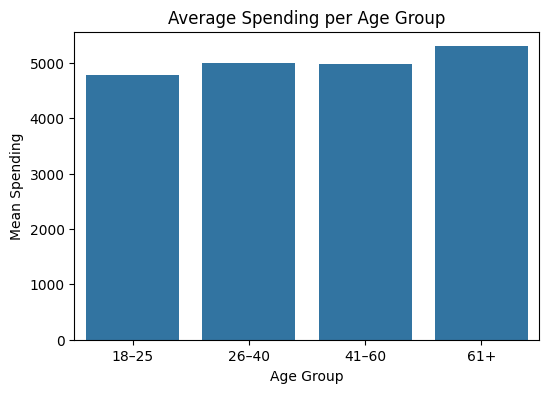

```python
import pandas as pd
import numpy as np
import seaborn as sns
import matplotlib.pyplot as plt

# Dummy data
np.random.seed(42)
data = pd.DataFrame({
    'age': np.random.randint(18, 70, 200),
    'spending': np.random.normal(5000, 1500, 200)
})
data['age_group'] = pd.cut(data['age'], bins=[17, 25, 40, 60, 80], labels=['18–25', '26–40', '41–60', '61+'])

# Grouping and plotting
grouped = data.groupby('age_group', observed=True)['spending'].mean().reset_index()

plt.figure(figsize=(6,4))
sns.barplot(data=grouped, x='age_group', y='spending')
plt.title("Average Spending per Age Group")
plt.ylabel("Mean Spending")
plt.xlabel("Age Group")
plt.show()
```

#### At this Stage, Ask Yourself:

- **Do the results support the hypothesis?** If 26–40 has the highest bar, the hypothesis is supported.
- **Are there outliers that could skew the result?**
- **Are these differences statistically significant?**
- **Could other variables explain the behavior better?** Perhaps income is the real driver, not age.

### **Come Up With General Insight**

Once the hypothesis is tested, and you've either validated or rejected it, the next step is to **translate the result into a practical, interpretable insight**.

#### If the Hypothesis Was True:

You might say:

> “The data confirms that customers aged 26–40 tend to spend significantly more on average. This suggests that marketing campaigns targeting this group could yield higher returns.”

#### Either Way, the Insight Should Answer:

- **What did we learn?**
- **Why does this matter?**
- **How can this influence our decisions or actions?**

## Types of Questions to Keep Asking Through EDA

Throughout the entire hypothesis-testing loop, the **key to getting meaningful insights** lies in constantly questioning and interpreting.

| Stage | Example Questions | Purpose |
| --- | --- | --- |
| Formulating Hypothesis | What business outcome do I want to influence? | Define direction |
| While Analyzing | Is this distribution normal or skewed? | Understand shape |
| While Plotting | Are there clear trends or clusters? | Detect relationships |
| While Grouping | Which groups stand out in behavior? | Compare segments |
| Interpreting Results | Does this pattern align with domain knowledge? | Validate |

## Let’s Do a Full Example

### Business Context:

You're analyzing customer data for a retail company.

### Hypothesis:

**“Customers from Tier 1 cities purchase more frequently than those from Tier 2/3 cities.”**

### Testing:

- Group customers by city tier.
- Compute average purchase frequency.
- Plot the results using bar chart.
- Check for variability or exceptions.

### Result:

If Tier 1 has significantly higher purchase frequency → insight validated.

### General Insight:

> “Customers from Tier 1 cities are more active buyers. Future engagement strategies can prioritize these areas, while efforts to improve buying behavior in Tier 2/3 should focus on discounts or accessibility.”

## Recap of the Process

### 1. **Propose a Hypothesis**

→ Frame a **specific, testable assumption** based on the problem context.

### 2. **Test it Using EDA**

→ Use visuals, grouping, statistical summaries, and exploratory techniques.

### 3. **Generate General Insight**

→ Translate findings into **meaningful conclusions**, ready to influence modeling decisions or business actions.

This cycle is the **intellectual engine** of EDA. Rather than dumping data into a model blindly, it encourages thoughtful examination, **data-driven thinking**, and well-supported decisions.

## **Conclusion: EDA as a Foundation, Not a Precursor**

Exploratory Data Analysis is not a box to tick off—it is the **foundation upon which every modeling decision stands**. It helps you grasp the language your data speaks. By examining nulls, outliers, distributions, and relationships, you build a mental model of your data, which guides preprocessing, model selection, and evaluation strategy.

A strong EDA not only increases your chances of building an accurate model—it also gives you confidence in your results, and the ability to explain your findings to stakeholders, regulators, and decision-makers in a language they understand. EDA is not merely a phase before modeling—it is **data reasoning** in action. Visuals like scatterplots, heatmaps, bar charts, and line charts uncover **hidden patterns**, **relationships**, and **anomalies** that statistical summaries alone cannot show. However, to interpret these insights responsibly, it’s critical to distinguish correlation from causation, especially when drawing **business conclusions** or deploying **predictive models**.